# Risk Factor Analysis

## Outcome Variable

**Outcome Variable:** ever_co

## Predictor Variables

**Intervention Variable:** perdiar6

**Adjustment Set:**

- arm
- sex
- W_mage
- meducyrs
- W_mhtcm
- W_mwtkg
- W_mbmi
- W_birthwt
- W_birthlen
- W_nrooms
- month
- brthmon
- impfloor
- impsan
- safeh20
- delta_W_mage
- delta_meducyrs
- delta_W_mhtcm
- delta_W_mwtkg
- delta_W_mbmi
- delta_W_birthwt
- delta_W_birthlen
- delta_W_nrooms
- delta_month
- delta_brthmon
- delta_impfloor
- delta_impsan
- delta_safeh20

## Stratifying Variables

The analysis was stratified on these variable(s):

- agecat
- studyid
- country

## Data Summary

| agecat | studyid | country | perdiar6 | ever_co | n_cell | n |
| --- | --- | --- | --- | --- | --- | --- |
| 0-24 months | ki0047075b-MAL-ED | BANGLADESH | 0% | 0 | 70 | 263 |
| 0-24 months | ki0047075b-MAL-ED | BANGLADESH | 0% | 1 | 15 | 263 |
| 0-24 months | ki0047075b-MAL-ED | BANGLADESH | (0%, 5%] | 0 | 83 | 263 |
| 0-24 months | ki0047075b-MAL-ED | BANGLADESH | (0%, 5%] | 1 | 15 | 263 |
| 0-24 months | ki0047075b-MAL-ED | BANGLADESH | >5% | 0 | 71 | 263 |
| 0-24 months | ki0047075b-MAL-ED | BANGLADESH | >5% | 1 | 9 | 263 |
| 0-24 months | ki0047075b-MAL-ED | BRAZIL | 0% | 0 | 214 | 233 |
| 0-24 months | ki0047075b-MAL-ED | BRAZIL | 0% | 1 | 2 | 233 |
| 0-24 months | ki0047075b-MAL-ED | BRAZIL | (0%, 5%] | 0 | 15 | 233 |
| 0-24 months | ki0047075b-MAL-ED | BRAZIL | (0%, 5%] | 1 | 0 | 233 |
| 0-24 months | ki0047075b-MAL-ED | BRAZIL | >5% | 0 | 2 | 233 |
| 0-24 months | ki0047075b-MAL-ED | BRAZIL | >5% | 1 | 0 | 233 |
| 0-24 months | ki0047075b-MAL-ED | INDIA | 0% | 0 | 46 | 251 |
| 0-24 months | ki0047075b-MAL-ED | INDIA | 0% | 1 | 15 | 251 |
| 0-24 months | ki0047075b-MAL-ED | INDIA | (0%, 5%] | 0 | 105 | 251 |
| 0-24 months | ki0047075b-MAL-ED | INDIA | (0%, 5%] | 1 | 24 | 251 |
| 0-24 months | ki0047075b-MAL-ED | INDIA | >5% | 0 | 46 | 251 |
| 0-24 months | ki0047075b-MAL-ED | INDIA | >5% | 1 | 15 | 251 |
| 0-24 months | ki0047075b-MAL-ED | NEPAL | 0% | 0 | 73 | 240 |
| 0-24 months | ki0047075b-MAL-ED | NEPAL | 0% | 1 | 10 | 240 |
| 0-24 months | ki0047075b-MAL-ED | NEPAL | (0%, 5%] | 0 | 73 | 240 |
| 0-24 months | ki0047075b-MAL-ED | NEPAL | (0%, 5%] | 1 | 4 | 240 |
| 0-24 months | ki0047075b-MAL-ED | NEPAL | >5% | 0 | 73 | 240 |
| 0-24 months | ki0047075b-MAL-ED | NEPAL | >5% | 1 | 7 | 240 |
| 0-24 months | ki0047075b-MAL-ED | PERU | 0% | 0 | 84 | 302 |
| 0-24 months | ki0047075b-MAL-ED | PERU | 0% | 1 | 5 | 302 |
| 0-24 months | ki0047075b-MAL-ED | PERU | (0%, 5%] | 0 | 89 | 302 |
| 0-24 months | ki0047075b-MAL-ED | PERU | (0%, 5%] | 1 | 4 | 302 |
| 0-24 months | ki0047075b-MAL-ED | PERU | >5% | 0 | 117 | 302 |
| 0-24 months | ki0047075b-MAL-ED | PERU | >5% | 1 | 3 | 302 |

[output cut: 258 more lines]

The following strata were considered:

- agecat: 0-24 months, studyid: ki0047075b-MAL-ED, country: BANGLADESH
- agecat: 0-24 months, studyid: ki0047075b-MAL-ED, country: BRAZIL
- agecat: 0-24 months, studyid: ki0047075b-MAL-ED, country: INDIA
- agecat: 0-24 months, studyid: ki0047075b-MAL-ED, country: NEPAL
- agecat: 0-24 months, studyid: ki0047075b-MAL-ED, country: PERU
- agecat: 0-24 months, studyid: ki0047075b-MAL-ED, country: SOUTH AFRICA
- agecat: 0-24 months, studyid: ki0047075b-MAL-ED, country: TANZANIA, UNITED REPUBLIC OF
- agecat: 0-24 months, studyid: ki1000109-ResPak, country: PAKISTAN
- agecat: 0-24 months, studyid: ki1017093-NIH-Birth, country: BANGLADESH
- agecat: 0-24 months, studyid: ki1017093b-PROVIDE, country: BANGLADESH
- agecat: 0-24 months, studyid: ki1017093c-NIH-Crypto, country: BANGLADESH
- agecat: 0-24 months, studyid: ki1114097-CMIN, country: BANGLADESH
- agecat: 0-24 months, studyid: ki1114097-CMIN, country: BRAZIL
- agecat: 0-24 months, studyid: ki1114097-CMIN, country: GUINEA-BISSAU
- agecat: 0-24 months, studyid: ki1114097-CMIN, country: PERU
- agecat: 0-24 months, studyid: ki1114097-CONTENT, country: PERU
- agecat: 0-6 months, studyid: ki0047075b-MAL-ED, country: BANGLADESH
- agecat: 0-6 months, studyid: ki0047075b-MAL-ED, country: BRAZIL
- agecat: 0-6 months, studyid: ki0047075b-MAL-ED, country: INDIA
- agecat: 0-6 months, studyid: ki0047075b-MAL-ED, country: NEPAL
- agecat: 0-6 months, studyid: ki0047075b-MAL-ED, country: PERU
- agecat: 0-6 months, studyid: ki0047075b-MAL-ED, country: SOUTH AFRICA
- agecat: 0-6 months, studyid: ki0047075b-MAL-ED, country: TANZANIA, UNITED REPUBLIC OF
- agecat: 0-6 months, studyid: ki1000109-ResPak, country: PAKISTAN
- agecat: 0-6 months, studyid: ki1017093-NIH-Birth, country: BANGLADESH
- agecat: 0-6 months, studyid: ki1017093b-PROVIDE, country: BANGLADESH
- agecat: 0-6 months, studyid: ki1017093c-NIH-Crypto, country: BANGLADESH
- agecat: 0-6 months, studyid: ki1114097-CMIN, country: BANGLADESH
- agecat: 0-6 months, studyid: ki1114097-CMIN, country: BRAZIL
- agecat: 0-6 months, studyid: ki1114097-CMIN, country: GUINEA-BISSAU
- agecat: 0-6 months, studyid: ki1114097-CMIN, country: PERU
- agecat: 0-6 months, studyid: ki1114097-CONTENT, country: PERU
- agecat: 6-24 months, studyid: ki0047075b-MAL-ED, country: BANGLADESH
- agecat: 6-24 months, studyid: ki0047075b-MAL-ED, country: BRAZIL
- agecat: 6-24 months, studyid: ki0047075b-MAL-ED, country: INDIA
- agecat: 6-24 months, studyid: ki0047075b-MAL-ED, country: NEPAL
- agecat: 6-24 months, studyid: ki0047075b-MAL-ED, country: PERU
- agecat: 6-24 months, studyid: ki0047075b-MAL-ED, country: SOUTH AFRICA
- agecat: 6-24 months, studyid: ki0047075b-MAL-ED, country: TANZANIA, UNITED REPUBLIC OF
- agecat: 6-24 months, studyid: ki1000109-ResPak, country: PAKISTAN
- agecat: 6-24 months, studyid: ki1017093-NIH-Birth, country: BANGLADESH
- agecat: 6-24 months, studyid: ki1017093b-PROVIDE, country: BANGLADESH
- agecat: 6-24 months, studyid: ki1017093c-NIH-Crypto, country: BANGLADESH
- agecat: 6-24 months, studyid: ki1114097-CMIN, country: BANGLADESH
- agecat: 6-24 months, studyid: ki1114097-CMIN, country: BRAZIL
- agecat: 6-24 months, studyid: ki1114097-CMIN, country: GUINEA-BISSAU
- agecat: 6-24 months, studyid: ki1114097-CMIN, country: PERU
- agecat: 6-24 months, studyid: ki1114097-CONTENT, country: PERU

### Dropped Strata

Some strata were dropped due to rare outcomes:

- agecat: 0-24 months, studyid: ki0047075b-MAL-ED, country: BRAZIL
- agecat: 0-24 months, studyid: ki0047075b-MAL-ED, country: NEPAL
- agecat: 0-24 months, studyid: ki0047075b-MAL-ED, country: PERU
- agecat: 0-24 months, studyid: ki0047075b-MAL-ED, country: SOUTH AFRICA
- agecat: 0-24 months, studyid: ki0047075b-MAL-ED, country: TANZANIA, UNITED REPUBLIC OF
- agecat: 0-24 months, studyid: ki1000109-ResPak, country: PAKISTAN
- agecat: 0-24 months, studyid: ki1114097-CMIN, country: BRAZIL
- agecat: 0-24 months, studyid: ki1114097-CONTENT, country: PERU
- agecat: 0-6 months, studyid: ki0047075b-MAL-ED, country: BANGLADESH
- agecat: 0-6 months, studyid: ki0047075b-MAL-ED, country: BRAZIL
- agecat: 0-6 months, studyid: ki0047075b-MAL-ED, country: NEPAL
- agecat: 0-6 months, studyid: ki0047075b-MAL-ED, country: PERU
- agecat: 0-6 months, studyid: ki0047075b-MAL-ED, country: SOUTH AFRICA
- agecat: 0-6 months, studyid: ki0047075b-MAL-ED, country: TANZANIA, UNITED REPUBLIC OF
- agecat: 0-6 months, studyid: ki1000109-ResPak, country: PAKISTAN
- agecat: 0-6 months, studyid: ki1017093c-NIH-Crypto, country: BANGLADESH
- agecat: 0-6 months, studyid: ki1114097-CMIN, country: BANGLADESH
- agecat: 0-6 months, studyid: ki1114097-CMIN, country: BRAZIL
- agecat: 0-6 months, studyid: ki1114097-CMIN, country: GUINEA-BISSAU
- agecat: 0-6 months, studyid: ki1114097-CMIN, country: PERU
- agecat: 0-6 months, studyid: ki1114097-CONTENT, country: PERU
- agecat: 6-24 months, studyid: ki0047075b-MAL-ED, country: BRAZIL
- agecat: 6-24 months, studyid: ki0047075b-MAL-ED, country: NEPAL
- agecat: 6-24 months, studyid: ki0047075b-MAL-ED, country: PERU
- agecat: 6-24 months, studyid: ki0047075b-MAL-ED, country: SOUTH AFRICA
- agecat: 6-24 months, studyid: ki0047075b-MAL-ED, country: TANZANIA, UNITED REPUBLIC OF
- agecat: 6-24 months, studyid: ki1000109-ResPak, country: PAKISTAN
- agecat: 6-24 months, studyid: ki1114097-CMIN, country: BRAZIL
- agecat: 6-24 months, studyid: ki1114097-CMIN, country: PERU
- agecat: 6-24 months, studyid: ki1114097-CONTENT, country: PERU

## Methods Detail

We’re interested in the causal parameters $E[Y_a]$ for all values of $a \in \mathcal{A}$. These parameters represent the mean outcome if, possibly contrary to fact, we intervened to set all units to have $A=a$. Under the randomization and positivity assumptions, these are identified by the statistical parameters $\psi_a=E_W[E_{Y|A,W}(Y|A=a,W)]$. In addition, we’re interested in the mean of $Y$, $E[Y]$ under no intervention (the observed mean). We will estimate these parameters by using SuperLearner to fit the relevant likelihood factors – $E_{Y|A,W}(Y|A=a,W)$ and $p(A=a|W)$, and then updating our likelihood fit using a joint TMLE.

For unadjusted analyses ($W=\{\}$), initial likelihoods were estimated using Lrnr_glm to estimate the simple $E(Y|A)$ and Lrnr_mean to estimate $p(A)$. For adjusted analyses, a small library containing Lrnr_glmnet, Lrnr_xgboost, and Lrnr_mean was used.

Having estimated these parameters, we will then use the delta method to estimate relative risks and attributable risks relative to a prespecified baseline level of $A$.

# Results Detail

## Results Plots

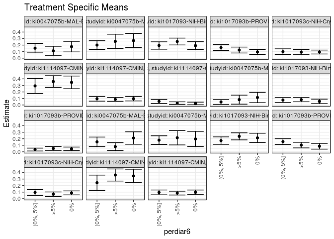

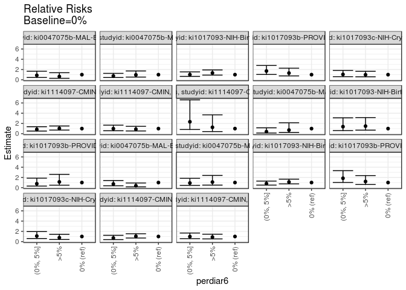

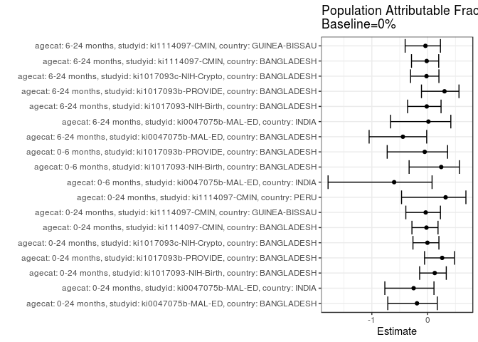

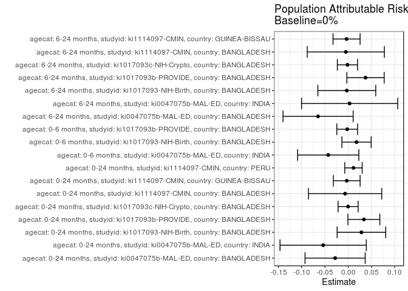

## Results Table

### Parameter: TSM

| agecat | studyid | country | intervention_level | baseline_level | estimate | ci_lower | ci_upper |
| --- | --- | --- | --- | --- | --- | --- | --- |
| 0-24 months | ki0047075b-MAL-ED | BANGLADESH | 0% | NA | 0.1764706 | 0.0952733 | 0.2576679 |
| 0-24 months | ki0047075b-MAL-ED | BANGLADESH | (0%, 5%] | NA | 0.1530612 | 0.0816411 | 0.2244814 |
| 0-24 months | ki0047075b-MAL-ED | BANGLADESH | >5% | NA | 0.1125000 | 0.0431270 | 0.1818730 |
| 0-24 months | ki0047075b-MAL-ED | INDIA | 0% | NA | 0.2690016 | 0.1608924 | 0.3771108 |
| 0-24 months | ki0047075b-MAL-ED | INDIA | (0%, 5%] | NA | 0.2004218 | 0.1337169 | 0.2671267 |
| 0-24 months | ki0047075b-MAL-ED | INDIA | >5% | NA | 0.2568897 | 0.1464907 | 0.3672887 |
| 0-24 months | ki1017093-NIH-Birth | BANGLADESH | 0% | NA | 0.1921819 | 0.1324960 | 0.2518678 |
| 0-24 months | ki1017093-NIH-Birth | BANGLADESH | (0%, 5%] | NA | 0.1939593 | 0.1374016 | 0.2505170 |
| 0-24 months | ki1017093-NIH-Birth | BANGLADESH | >5% | NA | 0.2549114 | 0.2023119 | 0.3075110 |
| 0-24 months | ki1017093b-PROVIDE | BANGLADESH | 0% | NA | 0.0949136 | 0.0561114 | 0.1337158 |
| 0-24 months | ki1017093b-PROVIDE | BANGLADESH | (0%, 5%] | NA | 0.1619606 | 0.1169332 | 0.2069880 |
| 0-24 months | ki1017093b-PROVIDE | BANGLADESH | >5% | NA | 0.1243584 | 0.0790536 | 0.1696633 |
| 0-24 months | ki1017093c-NIH-Crypto | BANGLADESH | 0% | NA | 0.0939027 | 0.0639490 | 0.1238563 |
| 0-24 months | ki1017093c-NIH-Crypto | BANGLADESH | (0%, 5%] | NA | 0.0989678 | 0.0547494 | 0.1431862 |
| 0-24 months | ki1017093c-NIH-Crypto | BANGLADESH | >5% | NA | 0.0921080 | 0.0538302 | 0.1303859 |
| 0-24 months | ki1114097-CMIN | BANGLADESH | 0% | NA | 0.3462189 | 0.2489314 | 0.4435065 |
| 0-24 months | ki1114097-CMIN | BANGLADESH | (0%, 5%] | NA | 0.2923888 | 0.1772755 | 0.4075021 |
| 0-24 months | ki1114097-CMIN | BANGLADESH | >5% | NA | 0.3594802 | 0.2704070 | 0.4485533 |
| 0-24 months | ki1114097-CMIN | GUINEA-BISSAU | 0% | NA | 0.0970683 | 0.0621331 | 0.1320035 |
| 0-24 months | ki1114097-CMIN | GUINEA-BISSAU | (0%, 5%] | NA | 0.0957538 | 0.0590572 | 0.1324504 |
| 0-24 months | ki1114097-CMIN | GUINEA-BISSAU | >5% | NA | 0.0858618 | 0.0571251 | 0.1145985 |
| 0-24 months | ki1114097-CMIN | PERU | 0% | NA | 0.0235849 | 0.0031432 | 0.0440266 |
| 0-24 months | ki1114097-CMIN | PERU | (0%, 5%] | NA | 0.0550000 | 0.0233821 | 0.0866179 |
| 0-24 months | ki1114097-CMIN | PERU | >5% | NA | 0.0295082 | 0.0105032 | 0.0485132 |
| 0-6 months | ki0047075b-MAL-ED | INDIA | 0% | NA | 0.1147541 | 0.0346110 | 0.1948972 |
| 0-6 months | ki0047075b-MAL-ED | INDIA | (0%, 5%] | NA | 0.0465116 | 0.0100985 | 0.0829248 |
| 0-6 months | ki0047075b-MAL-ED | INDIA | >5% | NA | 0.0819672 | 0.0129910 | 0.1509434 |
| 0-6 months | ki1017093-NIH-Birth | BANGLADESH | 0% | NA | 0.0548780 | 0.0199945 | 0.0897616 |
| 0-6 months | ki1017093-NIH-Birth | BANGLADESH | (0%, 5%] | NA | 0.0756757 | 0.0375337 | 0.1138177 |
| 0-6 months | ki1017093-NIH-Birth | BANGLADESH | >5% | NA | 0.0814815 | 0.0488234 | 0.1141396 |
| 0-6 months | ki1017093b-PROVIDE | BANGLADESH | 0% | NA | 0.0450450 | 0.0177429 | 0.0723472 |
| 0-6 months | ki1017093b-PROVIDE | BANGLADESH | (0%, 5%] | NA | 0.0344828 | 0.0123304 | 0.0566351 |
| 0-6 months | ki1017093b-PROVIDE | BANGLADESH | >5% | NA | 0.0506912 | 0.0214834 | 0.0798990 |
| 6-24 months | ki0047075b-MAL-ED | BANGLADESH | 0% | NA | 0.2112676 | 0.1161172 | 0.3064180 |
| 6-24 months | ki0047075b-MAL-ED | BANGLADESH | (0%, 5%] | NA | 0.1521739 | 0.0786230 | 0.2257248 |
| 6-24 months | ki0047075b-MAL-ED | BANGLADESH | >5% | NA | 0.0789474 | 0.0181951 | 0.1396997 |
| 6-24 months | ki0047075b-MAL-ED | INDIA | 0% | NA | 0.1970195 | 0.0795310 | 0.3145080 |
| 6-24 months | ki0047075b-MAL-ED | INDIA | (0%, 5%] | NA | 0.1783766 | 0.1114080 | 0.2453452 |
| 6-24 months | ki0047075b-MAL-ED | INDIA | >5% | NA | 0.2151050 | 0.1055816 | 0.3246284 |
| 6-24 months | ki1017093-NIH-Birth | BANGLADESH | 0% | NA | 0.2134064 | 0.1421674 | 0.2846454 |
| 6-24 months | ki1017093-NIH-Birth | BANGLADESH | (0%, 5%] | NA | 0.1716063 | 0.1145391 | 0.2286735 |
| 6-24 months | ki1017093-NIH-Birth | BANGLADESH | >5% | NA | 0.2367402 | 0.1827639 | 0.2907165 |
| 6-24 months | ki1017093b-PROVIDE | BANGLADESH | 0% | NA | 0.0849808 | 0.0408562 | 0.1291055 |
| 6-24 months | ki1017093b-PROVIDE | BANGLADESH | (0%, 5%] | NA | 0.1558969 | 0.1108903 | 0.2009035 |
| 6-24 months | ki1017093b-PROVIDE | BANGLADESH | >5% | NA | 0.1027655 | 0.0597830 | 0.1457481 |
| 6-24 months | ki1017093c-NIH-Crypto | BANGLADESH | 0% | NA | 0.0879569 | 0.0575874 | 0.1183263 |
| 6-24 months | ki1017093c-NIH-Crypto | BANGLADESH | (0%, 5%] | NA | 0.0957501 | 0.0503945 | 0.1411058 |
| 6-24 months | ki1017093c-NIH-Crypto | BANGLADESH | >5% | NA | 0.0680169 | 0.0335445 | 0.1024892 |
| 6-24 months | ki1114097-CMIN | BANGLADESH | 0% | NA | 0.3478006 | 0.2451428 | 0.4504584 |
| 6-24 months | ki1114097-CMIN | BANGLADESH | (0%, 5%] | NA | 0.2435270 | 0.1265653 | 0.3604886 |
| 6-24 months | ki1114097-CMIN | BANGLADESH | >5% | NA | 0.3617142 | 0.2691768 | 0.4542515 |
| 6-24 months | ki1114097-CMIN | GUINEA-BISSAU | 0% | NA | 0.0968412 | 0.0614936 | 0.1321887 |
| 6-24 months | ki1114097-CMIN | GUINEA-BISSAU | (0%, 5%] | NA | 0.0952800 | 0.0583196 | 0.1322403 |
| 6-24 months | ki1114097-CMIN | GUINEA-BISSAU | >5% | NA | 0.0850161 | 0.0559451 | 0.1140871 |

### Parameter: E(Y)

| agecat | studyid | country | intervention_level | baseline_level | estimate | ci_lower | ci_upper |
| --- | --- | --- | --- | --- | --- | --- | --- |
| 0-24 months | ki0047075b-MAL-ED | BANGLADESH | NA | NA | 0.1482890 | 0.1052563 | 0.1913216 |
| 0-24 months | ki0047075b-MAL-ED | INDIA | NA | NA | 0.2151394 | 0.1642023 | 0.2660766 |
| 0-24 months | ki1017093-NIH-Birth | BANGLADESH | NA | NA | 0.2206119 | 0.1879724 | 0.2532514 |
| 0-24 months | ki1017093b-PROVIDE | BANGLADESH | NA | NA | 0.1285714 | 0.1037574 | 0.1533855 |
| 0-24 months | ki1017093c-NIH-Crypto | BANGLADESH | NA | NA | 0.0936675 | 0.0729118 | 0.1144233 |
| 0-24 months | ki1114097-CMIN | BANGLADESH | NA | NA | 0.3394834 | 0.2830004 | 0.3959663 |
| 0-24 months | ki1114097-CMIN | GUINEA-BISSAU | NA | NA | 0.0938865 | 0.0749878 | 0.1127851 |
| 0-24 months | ki1114097-CMIN | PERU | NA | NA | 0.0348675 | 0.0214307 | 0.0483043 |
| 0-6 months | ki0047075b-MAL-ED | INDIA | NA | NA | 0.0717131 | 0.0397302 | 0.1036961 |
| 0-6 months | ki1017093-NIH-Birth | BANGLADESH | NA | NA | 0.0726979 | 0.0522275 | 0.0931683 |
| 0-6 months | ki1017093b-PROVIDE | BANGLADESH | NA | NA | 0.0428571 | 0.0278427 | 0.0578716 |
| 6-24 months | ki0047075b-MAL-ED | BANGLADESH | NA | NA | 0.1464435 | 0.1015265 | 0.1913605 |
| 6-24 months | ki0047075b-MAL-ED | INDIA | NA | NA | 0.2000000 | 0.1487493 | 0.2512507 |
| 6-24 months | ki1017093-NIH-Birth | BANGLADESH | NA | NA | 0.2103321 | 0.1759902 | 0.2446740 |
| 6-24 months | ki1017093b-PROVIDE | BANGLADESH | NA | NA | 0.1221498 | 0.0962275 | 0.1480722 |
| 6-24 months | ki1017093c-NIH-Crypto | BANGLADESH | NA | NA | 0.0863014 | 0.0659171 | 0.1066856 |
| 6-24 months | ki1114097-CMIN | BANGLADESH | NA | NA | 0.3426295 | 0.2837999 | 0.4014590 |
| 6-24 months | ki1114097-CMIN | GUINEA-BISSAU | NA | NA | 0.0932584 | 0.0741430 | 0.1123738 |

### Parameter: RR

| agecat | studyid | country | intervention_level | baseline_level | estimate | ci_lower | ci_upper |
| --- | --- | --- | --- | --- | --- | --- | --- |
| 0-24 months | ki0047075b-MAL-ED | BANGLADESH | 0% | 0% | 1.0000000 | 1.0000000 | 1.0000000 |
| 0-24 months | ki0047075b-MAL-ED | BANGLADESH | (0%, 5%] | 0% | 0.8673469 | 0.4503955 | 1.6702892 |
| 0-24 months | ki0047075b-MAL-ED | BANGLADESH | >5% | 0% | 0.6375000 | 0.2953502 | 1.3760149 |
| 0-24 months | ki0047075b-MAL-ED | INDIA | 0% | 0% | 1.0000000 | 1.0000000 | 1.0000000 |
| 0-24 months | ki0047075b-MAL-ED | INDIA | (0%, 5%] | 0% | 0.7450579 | 0.4434518 | 1.2517960 |
| 0-24 months | ki0047075b-MAL-ED | INDIA | >5% | 0% | 0.9549747 | 0.5300284 | 1.7206185 |
| 0-24 months | ki1017093-NIH-Birth | BANGLADESH | 0% | 0% | 1.0000000 | 1.0000000 | 1.0000000 |
| 0-24 months | ki1017093-NIH-Birth | BANGLADESH | (0%, 5%] | 0% | 1.0092484 | 0.6601971 | 1.5428459 |
| 0-24 months | ki1017093-NIH-Birth | BANGLADESH | >5% | 0% | 1.3264072 | 0.9149785 | 1.9228386 |
| 0-24 months | ki1017093b-PROVIDE | BANGLADESH | 0% | 0% | 1.0000000 | 1.0000000 | 1.0000000 |
| 0-24 months | ki1017093b-PROVIDE | BANGLADESH | (0%, 5%] | 0% | 1.7064007 | 1.0424971 | 2.7931048 |
| 0-24 months | ki1017093b-PROVIDE | BANGLADESH | >5% | 0% | 1.3102281 | 0.7577719 | 2.2654543 |
| 0-24 months | ki1017093c-NIH-Crypto | BANGLADESH | 0% | 0% | 1.0000000 | 1.0000000 | 1.0000000 |
| 0-24 months | ki1017093c-NIH-Crypto | BANGLADESH | (0%, 5%] | 0% | 1.0539399 | 0.6085489 | 1.8253081 |
| 0-24 months | ki1017093c-NIH-Crypto | BANGLADESH | >5% | 0% | 0.9808883 | 0.5809604 | 1.6561230 |
| 0-24 months | ki1114097-CMIN | BANGLADESH | 0% | 0% | 1.0000000 | 1.0000000 | 1.0000000 |
| 0-24 months | ki1114097-CMIN | BANGLADESH | (0%, 5%] | 0% | 0.8445199 | 0.5208329 | 1.3693718 |
| 0-24 months | ki1114097-CMIN | BANGLADESH | >5% | 0% | 1.0383031 | 0.7135255 | 1.5109107 |
| 0-24 months | ki1114097-CMIN | GUINEA-BISSAU | 0% | 0% | 1.0000000 | 1.0000000 | 1.0000000 |
| 0-24 months | ki1114097-CMIN | GUINEA-BISSAU | (0%, 5%] | 0% | 0.9864578 | 0.5830401 | 1.6690087 |
| 0-24 months | ki1114097-CMIN | GUINEA-BISSAU | >5% | 0% | 0.8845499 | 0.5411432 | 1.4458806 |
| 0-24 months | ki1114097-CMIN | PERU | 0% | 0% | 1.0000000 | 1.0000000 | 1.0000000 |
| 0-24 months | ki1114097-CMIN | PERU | (0%, 5%] | 0% | 2.3320000 | 0.8242181 | 6.5980403 |
| 0-24 months | ki1114097-CMIN | PERU | >5% | 0% | 1.2511475 | 0.4249566 | 3.6836005 |
| 0-6 months | ki0047075b-MAL-ED | INDIA | 0% | 0% | 1.0000000 | 1.0000000 | 1.0000000 |
| 0-6 months | ki0047075b-MAL-ED | INDIA | (0%, 5%] | 0% | 0.4053156 | 0.1419600 | 1.1572328 |
| 0-6 months | ki0047075b-MAL-ED | INDIA | >5% | 0% | 0.7142857 | 0.2392998 | 2.1320709 |
| 0-6 months | ki1017093-NIH-Birth | BANGLADESH | 0% | 0% | 1.0000000 | 1.0000000 | 1.0000000 |
| 0-6 months | ki1017093-NIH-Birth | BANGLADESH | (0%, 5%] | 0% | 1.3789790 | 0.6126960 | 3.1036321 |
| 0-6 months | ki1017093-NIH-Birth | BANGLADESH | >5% | 0% | 1.4847737 | 0.7003297 | 3.1478783 |
| 0-6 months | ki1017093b-PROVIDE | BANGLADESH | 0% | 0% | 1.0000000 | 1.0000000 | 1.0000000 |
| 0-6 months | ki1017093b-PROVIDE | BANGLADESH | (0%, 5%] | 0% | 0.7655172 | 0.3165046 | 1.8515265 |
| 0-6 months | ki1017093b-PROVIDE | BANGLADESH | >5% | 0% | 1.1253456 | 0.4876348 | 2.5970311 |
| 6-24 months | ki0047075b-MAL-ED | BANGLADESH | 0% | 0% | 1.0000000 | 1.0000000 | 1.0000000 |
| 6-24 months | ki0047075b-MAL-ED | BANGLADESH | (0%, 5%] | 0% | 0.7202899 | 0.3720423 | 1.3945120 |
| 6-24 months | ki0047075b-MAL-ED | BANGLADESH | >5% | 0% | 0.3736842 | 0.1532046 | 0.9114602 |
| 6-24 months | ki0047075b-MAL-ED | INDIA | 0% | 0% | 1.0000000 | 1.0000000 | 1.0000000 |
| 6-24 months | ki0047075b-MAL-ED | INDIA | (0%, 5%] | 0% | 0.9053753 | 0.4499811 | 1.8216420 |
| 6-24 months | ki0047075b-MAL-ED | INDIA | >5% | 0% | 1.0917955 | 0.5001539 | 2.3833009 |
| 6-24 months | ki1017093-NIH-Birth | BANGLADESH | 0% | 0% | 1.0000000 | 1.0000000 | 1.0000000 |
| 6-24 months | ki1017093-NIH-Birth | BANGLADESH | (0%, 5%] | 0% | 0.8041289 | 0.5023527 | 1.2871900 |
| 6-24 months | ki1017093-NIH-Birth | BANGLADESH | >5% | 0% | 1.1093397 | 0.7408777 | 1.6610496 |
| 6-24 months | ki1017093b-PROVIDE | BANGLADESH | 0% | 0% | 1.0000000 | 1.0000000 | 1.0000000 |
| 6-24 months | ki1017093b-PROVIDE | BANGLADESH | (0%, 5%] | 0% | 1.8344953 | 1.0143091 | 3.3178970 |
| 6-24 months | ki1017093b-PROVIDE | BANGLADESH | >5% | 0% | 1.2092789 | 0.6207133 | 2.3559273 |
| 6-24 months | ki1017093c-NIH-Crypto | BANGLADESH | 0% | 0% | 1.0000000 | 1.0000000 | 1.0000000 |
| 6-24 months | ki1017093c-NIH-Crypto | BANGLADESH | (0%, 5%] | 0% | 1.0886033 | 0.6057500 | 1.9563471 |
| 6-24 months | ki1017093c-NIH-Crypto | BANGLADESH | >5% | 0% | 0.7732979 | 0.4185866 | 1.4285924 |
| 6-24 months | ki1114097-CMIN | BANGLADESH | 0% | 0% | 1.0000000 | 1.0000000 | 1.0000000 |
| 6-24 months | ki1114097-CMIN | BANGLADESH | (0%, 5%] | 0% | 0.7001912 | 0.3978622 | 1.2322552 |
| 6-24 months | ki1114097-CMIN | BANGLADESH | >5% | 0% | 1.0400043 | 0.7036161 | 1.5372145 |
| 6-24 months | ki1114097-CMIN | GUINEA-BISSAU | 0% | 0% | 1.0000000 | 1.0000000 | 1.0000000 |
| 6-24 months | ki1114097-CMIN | GUINEA-BISSAU | (0%, 5%] | 0% | 0.9838785 | 0.5775930 | 1.6759500 |
| 6-24 months | ki1114097-CMIN | GUINEA-BISSAU | >5% | 0% | 0.8778916 | 0.5321558 | 1.4482481 |

### Parameter: PAR

| agecat | studyid | country | intervention_level | baseline_level | estimate | ci_lower | ci_upper |
| --- | --- | --- | --- | --- | --- | --- | --- |
| 0-24 months | ki0047075b-MAL-ED | BANGLADESH | 0% | NA | -0.0281816 | -0.0928591 | 0.0364958 |
| 0-24 months | ki0047075b-MAL-ED | INDIA | 0% | NA | -0.0538622 | -0.1466372 | 0.0389129 |
| 0-24 months | ki1017093-NIH-Birth | BANGLADESH | 0% | NA | 0.0284300 | -0.0237814 | 0.0806414 |
| 0-24 months | ki1017093b-PROVIDE | BANGLADESH | 0% | NA | 0.0336579 | -0.0006297 | 0.0679454 |
| 0-24 months | ki1017093c-NIH-Crypto | BANGLADESH | 0% | NA | -0.0002351 | -0.0218622 | 0.0213919 |
| 0-24 months | ki1114097-CMIN | BANGLADESH | 0% | NA | -0.0067355 | -0.0855108 | 0.0720397 |
| 0-24 months | ki1114097-CMIN | GUINEA-BISSAU | 0% | NA | -0.0031819 | -0.0319293 | 0.0255656 |
| 0-24 months | ki1114097-CMIN | PERU | 0% | NA | 0.0112826 | -0.0074606 | 0.0300258 |
| 0-6 months | ki0047075b-MAL-ED | INDIA | 0% | NA | -0.0430410 | -0.1087975 | 0.0227156 |
| 0-6 months | ki1017093-NIH-Birth | BANGLADESH | 0% | NA | 0.0178199 | -0.0136619 | 0.0493016 |
| 0-6 months | ki1017093b-PROVIDE | BANGLADESH | 0% | NA | -0.0021879 | -0.0245047 | 0.0201289 |
| 6-24 months | ki0047075b-MAL-ED | BANGLADESH | 0% | NA | -0.0648241 | -0.1402695 | 0.0106213 |
| 6-24 months | ki0047075b-MAL-ED | INDIA | 0% | NA | 0.0029805 | -0.1003856 | 0.1063466 |
| 6-24 months | ki1017093-NIH-Birth | BANGLADESH | 0% | NA | -0.0030743 | -0.0653131 | 0.0591644 |
| 6-24 months | ki1017093b-PROVIDE | BANGLADESH | 0% | NA | 0.0371690 | -0.0030077 | 0.0773457 |
| 6-24 months | ki1017093c-NIH-Crypto | BANGLADESH | 0% | NA | -0.0016555 | -0.0233900 | 0.0200790 |
| 6-24 months | ki1114097-CMIN | BANGLADESH | 0% | NA | -0.0051711 | -0.0881094 | 0.0777671 |
| 6-24 months | ki1114097-CMIN | GUINEA-BISSAU | 0% | NA | -0.0035827 | -0.0326875 | 0.0255220 |

### Parameter: PAF

| agecat | studyid | country | intervention_level | baseline_level | estimate | ci_lower | ci_upper |
| --- | --- | --- | --- | --- | --- | --- | --- |
| 0-24 months | ki0047075b-MAL-ED | BANGLADESH | 0% | NA | -0.1900452 | -0.7139097 | 0.1736976 |
| 0-24 months | ki0047075b-MAL-ED | INDIA | 0% | NA | -0.2503593 | -0.7667440 | 0.1150963 |
| 0-24 months | ki1017093-NIH-Birth | BANGLADESH | 0% | NA | 0.1288689 | -0.1423926 | 0.3357193 |
| 0-24 months | ki1017093b-PROVIDE | BANGLADESH | 0% | NA | 0.2617834 | -0.0540994 | 0.4830054 |
| 0-24 months | ki1017093c-NIH-Crypto | BANGLADESH | 0% | NA | -0.0025102 | -0.2621568 | 0.2037229 |
| 0-24 months | ki1114097-CMIN | BANGLADESH | 0% | NA | -0.0198406 | -0.2804022 | 0.1876968 |
| 0-24 months | ki1114097-CMIN | GUINEA-BISSAU | 0% | NA | -0.0338907 | -0.3900441 | 0.2310100 |
| 0-24 months | ki1114097-CMIN | PERU | 0% | NA | 0.3235849 | -0.4669086 | 0.6880942 |
| 0-6 months | ki0047075b-MAL-ED | INDIA | 0% | NA | -0.6001821 | -1.7855784 | 0.0807716 |
| 0-6 months | ki1017093-NIH-Birth | BANGLADESH | 0% | NA | 0.2451220 | -0.3311018 | 0.5719029 |
| 0-6 months | ki1017093b-PROVIDE | BANGLADESH | 0% | NA | -0.0510511 | -0.7245378 | 0.3594178 |
| 6-24 months | ki0047075b-MAL-ED | BANGLADESH | 0% | NA | -0.4426559 | -1.0488447 | -0.0158194 |
| 6-24 months | ki0047075b-MAL-ED | INDIA | 0% | NA | 0.0149025 | -0.6650065 | 0.4171692 |
| 6-24 months | ki1017093-NIH-Birth | BANGLADESH | 0% | NA | -0.0146165 | -0.3581892 | 0.2420448 |
| 6-24 months | ki1017093b-PROVIDE | BANGLADESH | 0% | NA | 0.3042903 | -0.1095012 | 0.5637571 |
| 6-24 months | ki1017093c-NIH-Crypto | BANGLADESH | 0% | NA | -0.0191829 | -0.3046990 | 0.2038518 |
| 6-24 months | ki1114097-CMIN | BANGLADESH | 0% | NA | -0.0150925 | -0.2884065 | 0.2002425 |
| 6-24 months | ki1114097-CMIN | GUINEA-BISSAU | 0% | NA | -0.0384174 | -0.4022563 | 0.2310173 |